# HOTEL_BOOKING

eric

2/26/2020

Visit my github account

# 1 HOTEL BOOKING DATASET

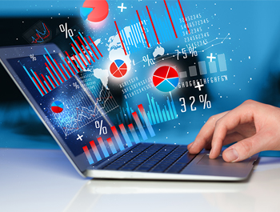

# 2 INTRODUCTION

1. *Ever wondered where and when is the best time to visit hotels*
2. *This data analysis is very helpful in facilitating making of informed decisions.*

## 2.1 PROJECT OBJECTIVE :

*To predict the best time,place and how to decision-make while there.*

# 3 PREPARATION OF DATA & PACKAGES

## 3.1 Loading the necessary library packages

```r
library(dbplyr)
library(tidyverse)
```

```r
library(ggplot2)
library(gganimate)
library(plotrix)
library(lubridate)
library(hrbrthemes)
library(plotly)
library(dygraphs)
library(png)
library(grid)
library(bootstrap)
library(gapminder)
```

## 3.2 *Importing data from the csv dataset*

```r
HOTEL_BOOKING <- read.csv("E:/Documents/class/FINAL_PROJECT/hotel_bookings.csv",stringsAsFactors = F)
```

# 4 DATA CLEANING

## 4.1 changing month name into numeric.

```r
HOTEL_BOOKING$arrival_date_month <-match(HOTEL_BOOKING$arrival_date_month,month.name)
str(HOTEL_BOOKING$arrival_date_month)
```

```
##  int [1:119390] 7 7 7 7 7 7 7 7 7 7 ...
```

```r
table(HOTEL_BOOKING$arrival_date_month)
```

```
##
##     1     2     3     4     5     6     7     8     9    10    11    12
##  5929  8068  9794 11089 11791 10939 12661 13877 10508 11160  6794  6780
```

```r
?match
```

```
## starting httpd help server ... done
```

# 5 DATA ANALYSIS & VISUALISATION

## 5.1 MONTHLY ADR

- **ADR = AVERAGE DAILY RATE**
- Its clear that in months 6,7,8 average costing rates are very high.
- Fortunetely months 1,2,11,3,12 have the best rates while rates increase respectively.

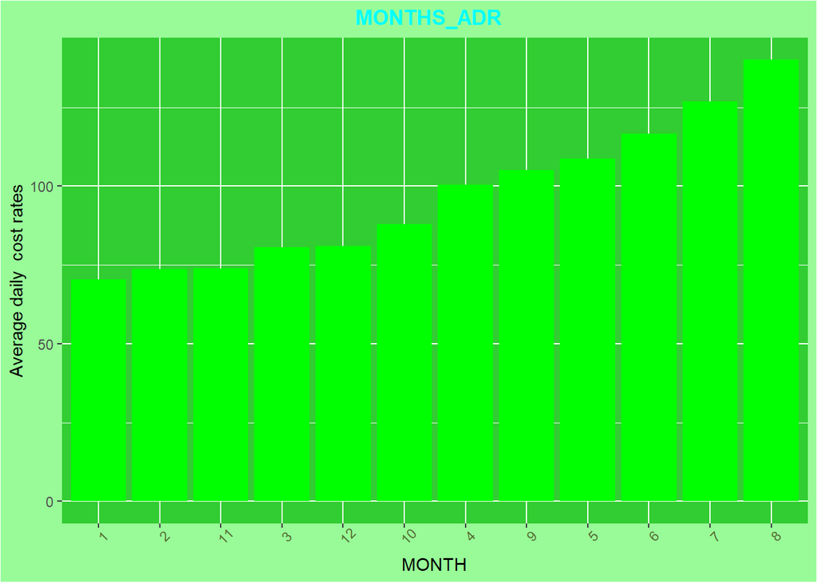

```r
MONTHS_ADR <- HOTEL_BOOKING%>%
  select(adr,arrival_date_month)%>%
  group_by(arrival_date_month)%>%
  summarise(adr = mean(adr))%>%
  arrange(desc(adr))

#VISUALIZATION
ggplot(MONTHS_ADR,aes(reorder(x=as.factor(arrival_date_month),adr),y=adr))+
  geom_bar(stat = "identity",position="dodge",fill="green")+
  labs(title = "MONTHS_ADR  ",x="MONTH",y="Average daily  cost rates")+
  theme(plot.title = element_text(hjust = 0.5,colour = "cyan",face = "bold"))+
  theme(panel.background = element_rect(fill = "limegreen"))+
  theme(axis.text.x = element_text(angle = 45,colour = "darkolivegreen"))+
  theme(plot.background = element_rect(fill="palegreen"))
```

## 5.2 DAILY ADR

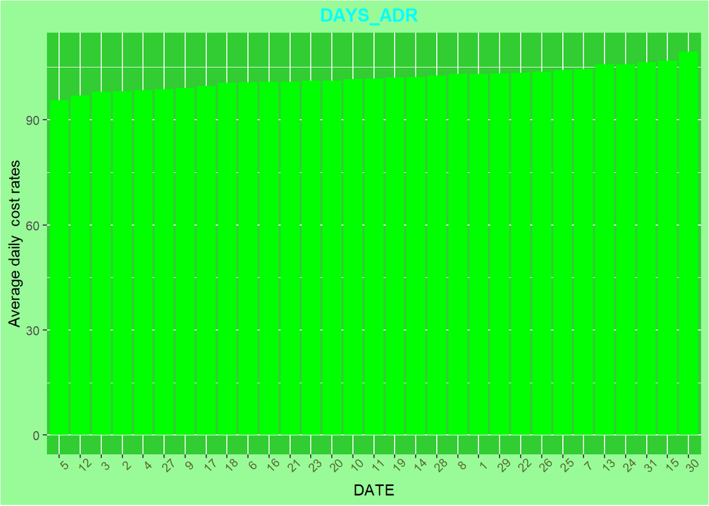

```r
DAYS_ADR <- HOTEL_BOOKING%>%
  select(adr,arrival_date_day_of_month)%>%
  group_by(arrival_date_day_of_month)%>%
  summarise(adr = mean(adr))%>%
  arrange(desc(adr))


#visualization
ggplot(DAYS_ADR,aes(reorder(x=as.factor(arrival_date_day_of_month),adr),y=adr))+
  geom_bar(stat = "identity",position="dodge",fill="green")+
  labs(title = "DAYS_ADR  ",x="DATE",y="Average daily  cost rates")+
  theme(plot.title = element_text(hjust = 0.5,colour = "cyan",face = "bold"))+
  theme(panel.background = element_rect(fill = "limegreen"))+
  theme(axis.text.x = element_text(angle = 45,colour = "darkolivegreen"))+
  theme(plot.background = element_rect(fill="palegreen"))
```

## 5.3 YEARLY ADR

- The above shows that through the years 2015,2016,2017 there has been a gradual increase in hotel costing rates.

[figure not shown]

```r
YEARS_ADR <- HOTEL_BOOKING%>%
  select(adr,arrival_date_year)%>%
  group_by(arrival_date_year)%>%
  summarise(adr = mean(adr))%>%
  arrange(desc(adr))

#VISUALIZATION
ggplot(YEARS_ADR,aes(reorder(x=as.factor(arrival_date_year),adr),y=adr))+
  geom_bar(stat = "identity",position="dodge",fill="green")+
  labs(title = "YEARS_ADR  ",x="YEAR",y="Average daily  cost rates")+
  theme(plot.title = element_text(hjust = 0.5,colour = "cyan",face = "bold"))+
  theme(panel.background = element_rect(fill = "limegreen"))+
  theme(axis.text.x = element_text(angle = 45,colour = "darkolivegreen"))+
  theme(plot.background = element_rect(fill="palegreen"))+
  transition_states(arrival_date_year,transition_length = 2, state_length = 1 )+
  ease_aes('sine-in-out')
```

```r
anim_save("years_adr_analysis.gif")
```

## 5.4 HOTELS ADR

- Its clear that CITY HOTEL has slightly a higher average costing RESORT HOTEL.

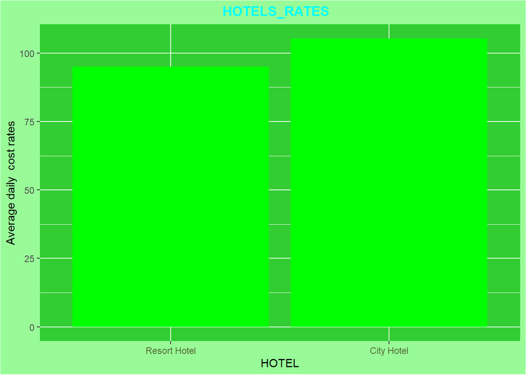

```r
HOTELS_RATES <- HOTEL_BOOKING%>%
  select(adr,hotel)%>%
  group_by(hotel)%>%
  summarise(adr = mean(adr))%>%
  arrange(desc(adr))


#VISUALIZATION

ggplot(HOTELS_RATES,aes(reorder(x=as.factor(hotel),adr),y=adr))+
  geom_bar(stat = "identity",position="dodge",fill="green")+
  labs(title = "HOTELS_RATES  ",x="HOTEL",y="Average daily  cost rates")+
  theme(plot.title = element_text(hjust = 0.5,colour = "cyan",face = "bold"))+
  theme(panel.background = element_rect(fill = "limegreen"))+
  theme(axis.text.x = element_text(angle = 0,colour = "darkolivegreen"))+
  theme(plot.background = element_rect(fill="palegreen"))
```

## 5.5 ADULTS VISITS OVER MONTHS

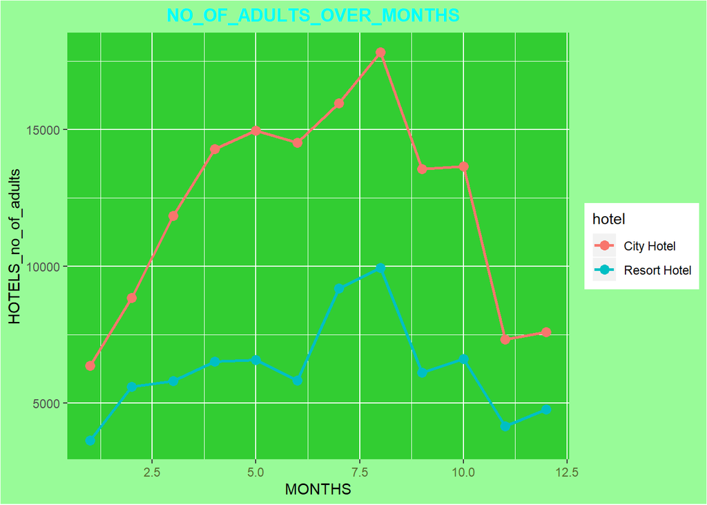

```r
NO_OF_ADULTS_OVER_MONTHS <- HOTEL_BOOKING%>%
  select(arrival_date_month,adults,hotel)%>%
  group_by(arrival_date_month,hotel)%>%
  summarise(no_of_adults = sum(adults))%>%
  arrange(desc(no_of_adults))

#VISUALIZATION
ggplot(NO_OF_ADULTS_OVER_MONTHS,aes(x=arrival_date_month,y=no_of_adults,col=hotel))+
geom_line(size=1)+
  geom_point(size=3)+
  geom_point(size=3,stat="identity",fill="green")+
  labs(title = "NO_OF_ADULTS_OVER_MONTHS  ",x="MONTHS",y="HOTELS_no_of_adults")+
  theme(plot.title = element_text(hjust = 0.5,colour = "cyan",face = "bold"))+
  theme(panel.background = element_rect(fill = "limegreen"))+
  theme(axis.text.x = element_text(angle = 0,colour = "darkolivegreen"))+
  theme(plot.background = element_rect(fill="palegreen"))
```

## 5.6 CANCELED_BOOKINGS_IN_HOTELS analysis

- Its observed that CITY HOTEL has a relatively higher number of cancelled hotel bookings than RESORT HOTEL.
- Precisely in months 5,6,7,8 booking cancelations are high in both hotels.

[figure not shown]

```r
MONTHS_FREQUENCY_OF_CANCELED_BOOKINGS_IN_HOTELS <- HOTEL_BOOKING%>%
  select(arrival_date_month,is_canceled,hotel)%>%
   filter(is_canceled==1)%>%
  group_by(arrival_date_month,hotel)%>%
  summarise(canceled_booking= n())%>%
  arrange(desc(canceled_booking))



 ggplot(MONTHS_FREQUENCY_OF_CANCELED_BOOKINGS_IN_HOTELS,aes(x=arrival_date_month,y=canceled_booking ,color=hotel))+
   geom_line(size=1)+
   geom_point(size=3)+
   labs(title = "MONTHS_FREQUENCY_OF_CANCELED_BOOKINGS  ",x="MONTHS",y="NO OF CANCELED HOTEL BOOKING")+
   theme(plot.title = element_text(hjust = 0.5,colour = "cyan",face = "bold"))+
   theme(panel.background = element_rect(fill = "limegreen"))+
   theme(axis.text.x = element_text(angle = 50,colour = "darkolivegreen"))+
   theme(plot.background = element_rect(fill="palegreen"))+
   transition_reveal(arrival_date_month)
```

```r
 anim_save("no_of_canceled_bookings.gif")
```

## 5.7 WAIT DAYS

- Its observed that in CITY HOTEL a customer has to wait relatively longer for a hotel booking to be confirmed compared to RESORT HOTEL.

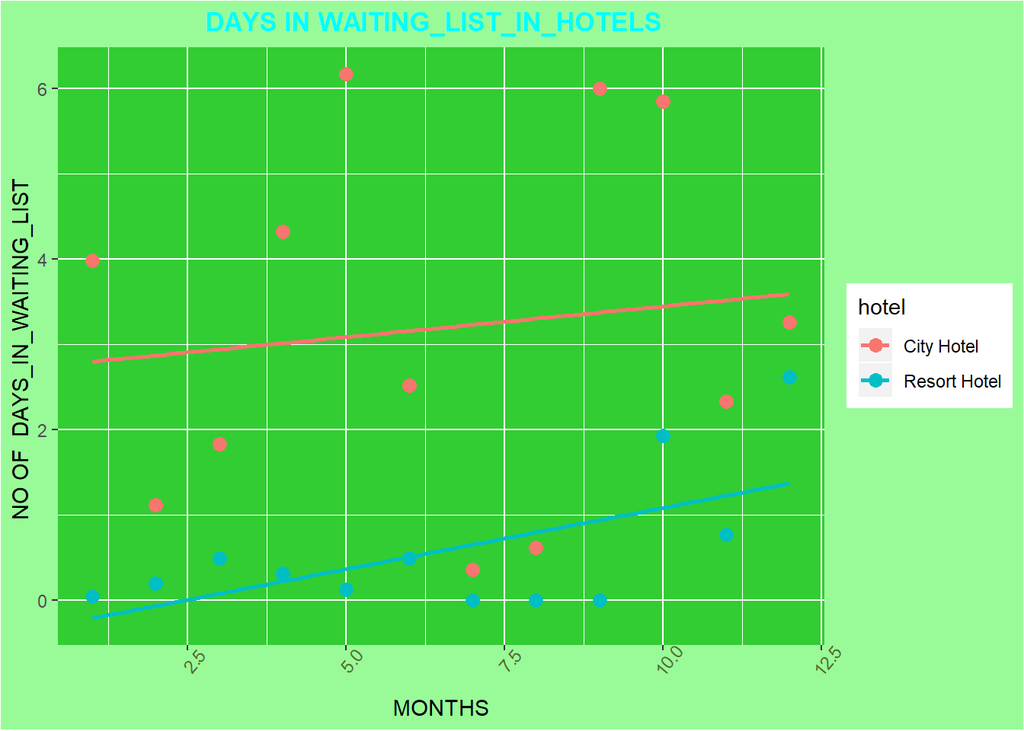

```r
DAYS_IN_WAITING_LIST_IN_HOTELS <- HOTEL_BOOKING%>%
   select(arrival_date_month,days_in_waiting_list,hotel)%>%
   group_by(arrival_date_month,hotel)%>%
   summarise(days_in_waiting_list=mean(days_in_waiting_list))%>%
   arrange(desc(days_in_waiting_list))


 #VISUALIZATION
 ggplot(DAYS_IN_WAITING_LIST_IN_HOTELS,aes(x=arrival_date_month,y=days_in_waiting_list ,color=hotel))+
   geom_point(size=3)+
   geom_smooth(method = "lm",se=F)+
   labs(title = "DAYS IN WAITING_LIST_IN_HOTELS  ",x="MONTHS",y="NO OF  DAYS_IN_WAITING_LIST ")+
   theme(plot.title = element_text(hjust = 0.5,colour = "cyan",face = "bold"))+
   theme(panel.background = element_rect(fill = "limegreen"))+
   theme(axis.text.x = element_text(angle = 50,colour = "darkolivegreen"))+
   theme(plot.background = element_rect(fill="palegreen"))
```

## 5.8 HOTEL RESERVATION STATUS

- The CITY HOTEL leads in canceled , check-outs and no-show hotel reservation statuses.
- This arguably because of its large scale service performance.

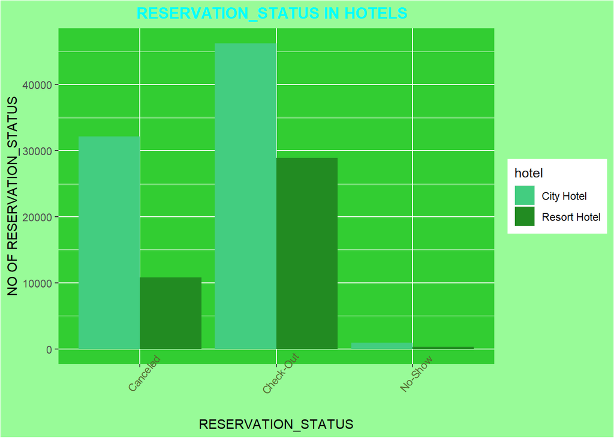

```r
RESERVATION_STATUS <- HOTEL_BOOKING%>%
   select(reservation_status,arrival_date_month,hotel)%>%
   group_by(reservation_status,hotel)%>%
   summarise(count= n())%>%
   arrange(desc(count))

 #VISUALIZATION
 ggplot(RESERVATION_STATUS,aes(y=count,x=reservation_status ,fill=hotel))+
   geom_bar(position="dodge",stat = "identity" )+
   scale_fill_manual(values = c("seagreen3","forestgreen"))+
   labs(title = "RESERVATION_STATUS IN HOTELS  ",x="RESERVATION_STATUS",y="NO OF RESERVATION_STATUS")+
   theme(plot.title = element_text(hjust = 0.5,colour = "cyan",face = "bold"))+
   theme(panel.background = element_rect(fill = "limegreen"))+
   theme(axis.text.x = element_text(angle = 50,colour = "darkolivegreen"))+
   theme(plot.background = element_rect(fill="palegreen"))
```

## 5.9 MEALS_perfomance

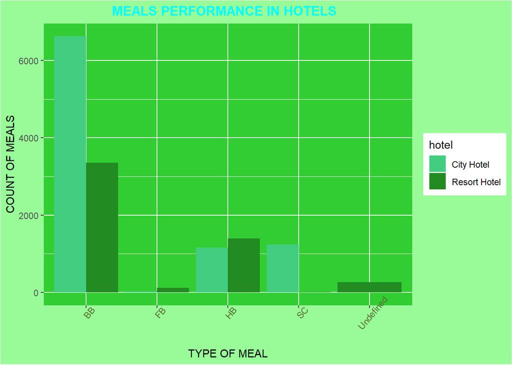

```r
MEALS_perfomance <- HOTEL_BOOKING%>%
   select(meal,hotel,arrival_date_month)%>%
   group_by(meal,hotel,arrival_date_month)%>%
   summarise(count= n())%>%
   arrange(desc(count))



 #VISUALIZATION
 ggplot(MEALS_perfomance,aes(y=count,x=meal ,fill=hotel))+
   geom_bar(position="dodge",stat = "identity" )+
   scale_fill_manual(values = c("seagreen3","forestgreen"))+
   labs(title = "MEALS PERFORMANCE IN HOTELS  ",x="TYPE OF MEAL",y="COUNT OF MEALS")+
   theme(plot.title = element_text(hjust = 0.5,colour = "cyan",face = "bold"))+
   theme(panel.background = element_rect(fill = "limegreen"))+
   theme(axis.text.x = element_text(angle = 50,colour = "darkolivegreen"))+
   theme(plot.background = element_rect(fill="palegreen"))
```

[figure not shown]

```r
 ggplot(MEALS_perfomance,aes(y=count,x=arrival_date_month ,col=meal,group=meal))+
   geom_line(size=1,stat = "identity" )+
   #scale_fill_manual(values = c("seagreen3","forestgreen","cyan","darkgreen","paleturquoise"))+
   labs(title = "MEALS PERFORMANCE IN HOTELS  ",x="month",y="COUNT OF MEALS")+
   theme(plot.title = element_text(hjust = 0.5,colour = "cyan",face = "bold"))+
   theme(panel.background = element_rect(fill = "limegreen"))+
   theme(axis.text.x = element_text(angle = 50,colour = "darkolivegreen"))+
   theme(plot.background = element_rect(fill="palegreen"))+
   transition_reveal(arrival_date_month)
```

```r
  anim_save("meals_performance.gif")
```

## 5.10 COUNTRY_OF_ORIGIN_perfomance

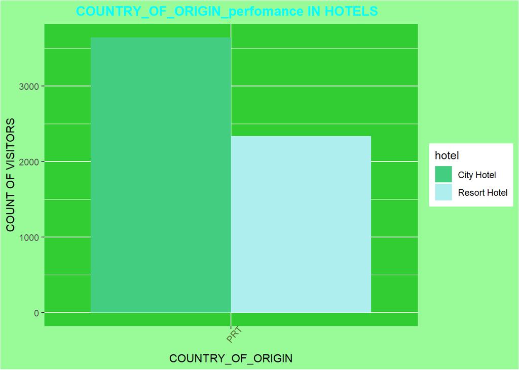

```r
COUNTRY_OF_ORIGIN_perfomance <- HOTEL_BOOKING%>%
   select(country,arrival_date_month,hotel)%>%
   group_by(country,arrival_date_month,hotel)%>%
   summarise(count= n())%>%
   arrange(desc(count))

 #DATA SORTING
 #Get a high performing sample of the data which is too huge.
 #Hence get the top 10 in rank.
 HEAD <- head(COUNTRY_OF_ORIGIN_perfomance,10)
 #get the bottom 10 in rank.
 TAIL <- tail(COUNTRY_OF_ORIGIN_perfomance,10)

 #VISUALIZATION

 ggplot(HEAD,aes(y=count,x=country ,fill=hotel))+
   geom_bar(position="dodge",stat = "identity" )+
   scale_fill_manual(values = c("seagreen3","paleturquoise"))+
   labs(title = "COUNTRY_OF_ORIGIN_perfomance IN HOTELS  ",x="COUNTRY_OF_ORIGIN",y="COUNT OF VISITORS")+
   theme(plot.title = element_text(hjust = 0.5,colour = "cyan",face = "bold"))+
   theme(panel.background = element_rect(fill = "limegreen"))+
   theme(axis.text.x = element_text(angle = 50,colour = "darkolivegreen"))+
   theme(plot.background = element_rect(fill="palegreen"))
```

## 5.11 ORIGIN_PERFORMANCE_OVER_MONTHS

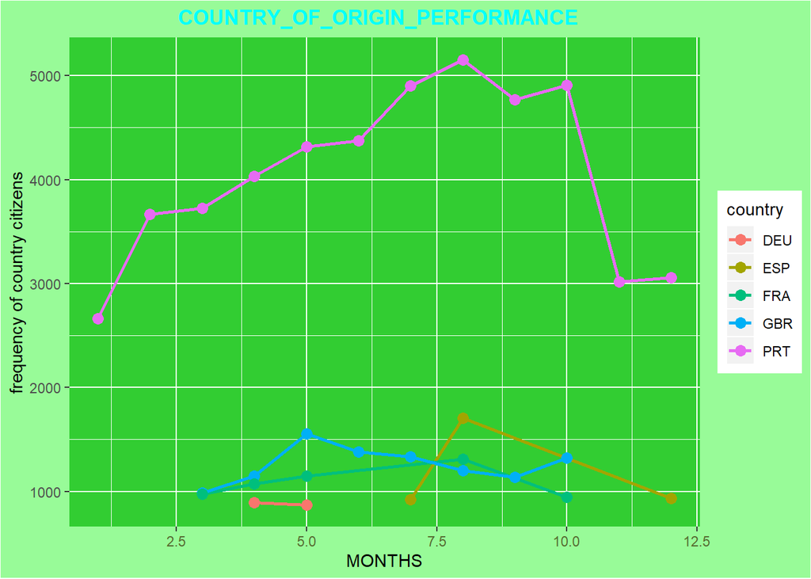

```r
COUNTRY_OF_ORIGIN_PERFORMANCE_OVER_MONTHS <- HOTEL_BOOKING%>%
   select(country,arrival_date_month,hotel)%>%
   group_by(country,arrival_date_month)%>%
   summarise(count= n())%>%
   arrange(desc(count))
 #Sampling of data to take the top 30 countrys of origin.
 HEAD2 <- head(COUNTRY_OF_ORIGIN_PERFORMANCE_OVER_MONTHS,30)


 #VISUALIZATION
 ggplot(HEAD2,aes(x=arrival_date_month,y=count,col=country))+
   geom_line(size=1)+
   geom_point(size=3,stat="identity")+
   labs(title = "COUNTRY_OF_ORIGIN_PERFORMANCE  ",x="MONTHS",y="frequency of country citizens")+
   theme(plot.title = element_text(hjust = 0.5,colour = "cyan",face = "bold"))+
   theme(panel.background = element_rect(fill = "limegreen"))+
   theme(axis.text.x = element_text(angle = 0,colour = "darkolivegreen"))+
   theme(plot.background = element_rect(fill="palegreen"))
```